# Extended War Report

2023-01-17

# Overview

This is an extended war report for the war **4056** between **Hasaryan Empire** and **The Den**. Data is presented from the side of **The Den**. Link to the official war report can be found [HERE](https://www.torn.com/war.php?step=rankreport&rankID=4056).

## Rewards

War outcome for your faction: **Victory**  
Total hits done: **581**  
War hits: **529**  
Non war hits: **52**  
Members contributed: **9/12**

Rewards for your faction:

| Name | Amount | Price |
| --- | --- | --- |
| Small Arms Cache | 1 | 391.19 M |
| Armor Cache | 1 | 699.32 M |
| Melee Cache | 1 | 480.03 M |

Points: **751**

Earnings from caches: **1.57 B**  
Earnings from points: **35.21 M**  
Total earnings: **1.61 B**<sup>1</sup>

<sup>1</sup>prices are based on market value or approximate trader prices if market value is unavaliable.

## War Preparation

Members who **did not stack** energy before war:

|  | Name | Prep_Xanax | Total_Hits |
| --- | --- | --- | --- |
| 1 | dugaxy | 3 | 104 |
| 2 | Killeraka45 | 2 | 38 |
| 3 | Exmorti | 1 | 33 |
| 4 | Caruljames | 2 | 23 |
| 5 | Omeg999 | 0 | 14 |
| 6 | janis | 3 | 94 |
| 7 | igors | 1 | 56 |
| 8 | Aziafeya | 1 | 0 |
| 9 | Wojmistrz | 0 | 0 |
| 10 | clamzy | 2 | 0 |

Members who **overdosed** during war preparations (but could still have stacked):

|  | Name | Prep_Xanax | Total_Hits |
| --- | --- | --- | --- |

Members who **most likely stacked** energy before war (or just used lots of xanax):

|  | Name | Prep_Xanax | Total_Hits |
| --- | --- | --- | --- |
| 1 | Kvother | 6 | 154 |
| 2 | Kingpigg3344 | 7 | 65 |

## Fighting summary

### Top 5

Top 5 by overall contribution %

| Name | Contribution |
| --- | --- |
| Kvother | 26.51 |
| dugaxy | 17.90 |
| janis | 16.18 |
| Kingpigg3344 | 11.19 |
| igors | 9.64 |

Top 5 by War hits

| Name | War_Hits |
| --- | --- |
| Kvother | 153 |
| dugaxy | 96 |
| janis | 75 |
| Kingpigg3344 | 63 |
| Killeraka45 | 38 |

Top 5 by Non War hits

| Name | Non_War_Hits |
| --- | --- |
| igors | 22 |
| janis | 19 |
| dugaxy | 8 |
| Kingpigg3344 | 2 |
| Kvother | 1 |

Top 5 by Total hits

| Name | Total_Hits |
| --- | --- |
| Kvother | 154 |
| dugaxy | 104 |
| janis | 94 |
| Kingpigg3344 | 65 |
| igors | 56 |

Top 5 by Assists

| Name | Assists |
| --- | --- |
| Kvother | 2 |
| Caruljames | 1 |
| Kingpigg3344 | 1 |
| dugaxy | 0 |
| Killeraka45 | 0 |

### Visual summary

Only including members with non-zero contribution

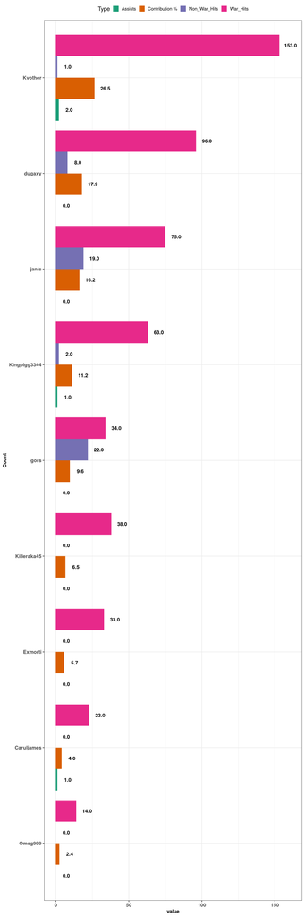

### Slackers

Members who did not meet 1% contribution cutoff

| Name | Contribution |
| --- | --- |
| Aziafeya | 0 |
| Wojmistrz | 0 |
| clamzy | 0 |

### Full table

Full table with filters and search

|  | Name | Total_Hits | Contribution | War_Hits | Non_War_Hits | Assists |
| --- | --- | --- | --- | --- | --- | --- |
| 1 | Kvother | 154 | 26.51 | 153 | 1 | 2 |
| 2 | dugaxy | 104 | 17.9 | 96 | 8 | 0 |
| 3 | Killeraka45 | 38 | 6.54 | 38 | 0 | 0 |
| 4 | Exmorti | 33 | 5.68 | 33 | 0 | 0 |
| 5 | Caruljames | 23 | 3.96 | 23 | 0 | 1 |
| 6 | Omeg999 | 14 | 2.41 | 14 | 0 | 0 |
| 7 | janis | 94 | 16.18 | 75 | 19 | 0 |
| 8 | igors | 56 | 9.64 | 34 | 22 | 0 |
| 9 | Kingpigg3344 | 65 | 11.19 | 63 | 2 | 1 |
| 10 | Aziafeya | 0 | 0 | 0 | 0 | 0 |

[output cut: 2 more lines]

## Extra details

### Xanax and refill usage

Xanax and Energy refill usage during the war.

Total Xanax used: **26**  
Xanax costs: **21.82 M**  
Total Refills used: **5**  
Refill costs: **5.86 M**

Drug cost in plot is in millions.

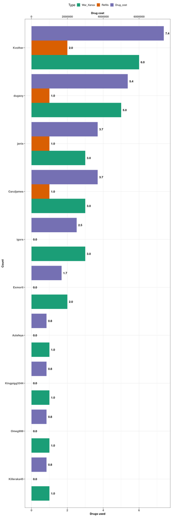

### Booster and can usage

Energy can and Booster usage during the war.

Total Boosters used: **6**  
Booster costs: **82.51 M**  
Total Cans used: **1**  
Can costs: **1.94 M**

All Boosters are assumed to be FHCs and Can price is set to average market value for ALL cans.

Booster cost in plot is in 10s of millions.

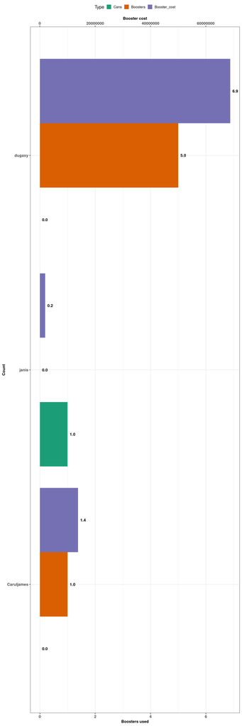

### Activity

Member activity during the war in hours.

```
## [1] "Correlation between activity and contribution:"
```

```
## [1] 0.93
```

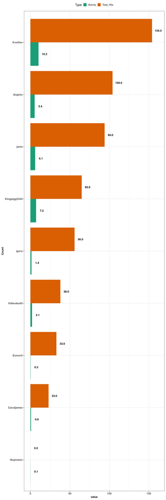

### Hospital

Summary of times hospitalized during the war

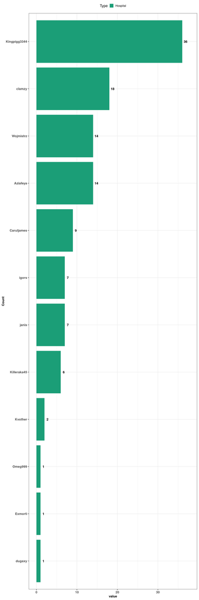

### Full table

|  | Name | War_Xanax | Refills | Boosters | Cans | Drug_cost | Booster_cost | Activity | Hospital |
| --- | --- | --- | --- | --- | --- | --- | --- | --- | --- |
| 1 | Kvother | 6 | 2 | 0 | 0 | 7379520 | 0 | 10.3 | 2 |
| 2 | dugaxy | 5 | 1 | 5 | 0 | 5368150 | 68757820 | 5.4 | 1 |
| 3 | Killeraka45 | 1 | 0 | 0 | 0 | 839195 | 0 | 2.15 | 6 |
| 4 | Exmorti | 2 | 0 | 0 | 0 | 1678390 | 0 | 0.28 | 1 |
| 5 | Caruljames | 3 | 1 | 1 | 0 | 3689760 | 13751564 | 0.9 | 9 |
| 6 | Omeg999 | 1 | 0 | 0 | 0 | 839195 | 0 | 0.05 | 1 |
| 7 | janis | 3 | 1 | 0 | 1 | 3689760 | 1937308.11 | 6.15 | 7 |
| 8 | igors | 3 | 0 | 0 | 0 | 2517585 | 0 | 1.4 | 7 |
| 9 | Kingpigg3344 | 1 | 0 | 0 | 0 | 839195 | 0 | 7.17 | 36 |
| 10 | Aziafeya | 1 | 0 | 0 | 0 | 839195 | 0 | 0.02 | 14 |

[output cut: 2 more lines]